# bm_group_project

## boxplot to find that something can be confounders

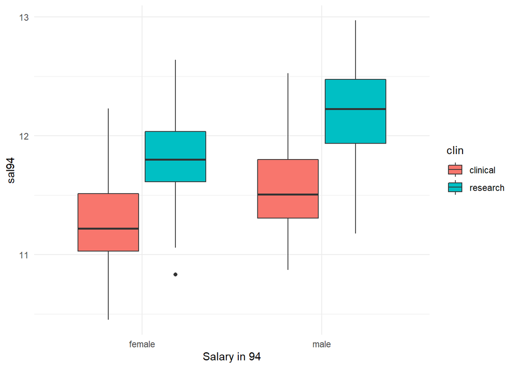

```r
law_df %>%
  ggplot(aes(y = sal94, x = gender))+
  geom_boxplot(aes(fill = clin))+
  labs(x = 'Salary in 94')
```

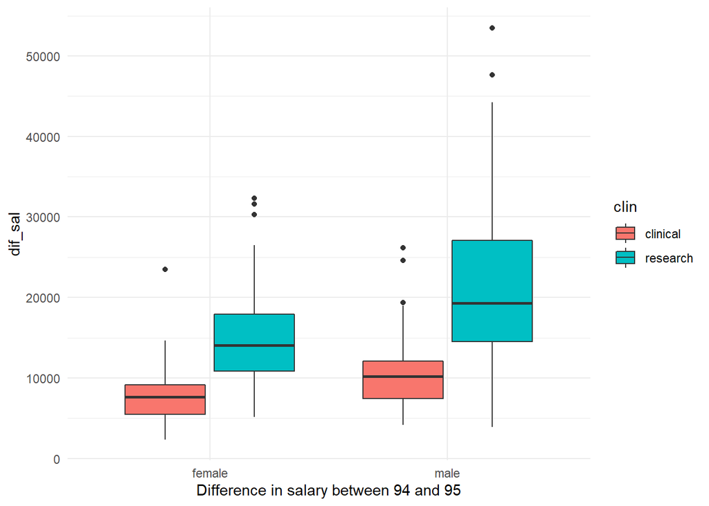

```r
law_df %>%
  ggplot(aes(y = dif_sal, x = gender))+
  geom_boxplot(aes(fill = clin))+
  labs(x = 'Difference in salary between 94 and 95')
```

## automatic stepwise trying—–After consulting another senior, this step may be useless at last

```r
full_ml <- lm(sal94 ~ dept + gender + clin + cert + prate + exper + rank, data = law_df)
step(full_ml, direction = 'backward')
```

```
## Start:  AIC=-1037.13
## sal94 ~ dept + gender + clin + cert + prate + exper + rank
##
##          Df Sum of Sq     RSS      AIC
## - gender  1    0.0190  4.4615 -1038.02
## - prate   1    0.0288  4.4713 -1037.45
## <none>                 4.4425 -1037.13
## - clin    1    0.2719  4.7143 -1023.63
## - rank    2    1.2528  5.6952  -976.30
## - cert    1    1.4736  5.9161  -964.37
## - exper   1    1.7301  6.1726  -953.29
## - dept    5    9.2120 13.6544  -754.07
##
## Step:  AIC=-1038.02
## sal94 ~ dept + clin + cert + prate + exper + rank
##
##         Df Sum of Sq     RSS      AIC
## <none>                4.4615 -1038.02
## - prate  1    0.0441  4.5056 -1037.45
## - clin   1    0.2537  4.7152 -1025.58
## - rank   2    1.3891  5.8506  -971.27
## - cert   1    1.4895  5.9510  -964.83
## - exper  1    1.8398  6.3013  -949.90
## - dept   5    9.4082 13.8697  -751.99
```

```
##
## Call:
## lm(formula = sal94 ~ dept + clin + cert + prate + exper + rank,
##     data = law_df)
##
## Coefficients:
##         (Intercept)       deptPhysiology         deptGenetics
##            11.13433             -0.17743              0.16608
##      deptPediatrics         deptMedicine          deptSurgery
##             0.13592              0.48950              0.86148
##        clinresearch  certBoard certified                prate
##             0.15175              0.19394             -0.02649
##               exper        rankassociate             rankfull
##             0.01829              0.13551              0.22428
```

```r
step(lm(sal94 ~ 1., data = law_df), direction = 'forward', trace = 1, scope = formula(full_ml))
```

```
## Start:  AIC=-352.29
## sal94 ~ 1
##
##          Df Sum of Sq    RSS     AIC
## + dept    5    48.472 18.689 -676.14
## + prate   1    39.484 27.676 -581.67
## + clin    1    24.754 42.407 -470.29
## + cert    1    16.509 50.652 -423.92
## + gender  1     9.391 57.770 -389.60
## + exper   1     6.673 60.488 -377.60
## + rank    2     3.624 63.537 -362.77
## <none>                67.161 -352.29
##
## Step:  AIC=-676.14
## sal94 ~ dept
##
##          Df Sum of Sq     RSS     AIC
## + exper   1    9.2415  9.4479 -852.19
## + rank    2    8.1547 10.5347 -821.77
## + cert    1    3.6100 15.0794 -730.16
## + gender  1    2.4239 16.2655 -710.40
## + clin    1    2.3691 16.3203 -709.52
## + prate   1    2.1499 16.5395 -706.04
## <none>                18.6894 -676.14
##
## Step:  AIC=-852.19
## sal94 ~ dept + exper
##
##          Df Sum of Sq    RSS     AIC
## + clin    1   2.03724 7.4106 -913.58
## + prate   1   1.91453 7.5333 -909.29
## + cert    1   1.88218 7.5657 -908.17
## + rank    2   1.44204 8.0058 -891.42
## + gender  1   0.25048 9.1974 -857.20
## <none>                9.4479 -852.19
##
## Step:  AIC=-913.58
## sal94 ~ dept + exper + clin
##
##          Df Sum of Sq    RSS     AIC
```

[output cut: 14 more lines]

```
##
## Step:  AIC=-1037.45
## sal94 ~ dept + exper + clin + cert + rank
##
##          Df Sum of Sq    RSS     AIC
## + prate   1  0.044150 4.4615 -1038.0
## <none>                4.5056 -1037.5
## + gender  1  0.034366 4.4713 -1037.5
##
## Step:  AIC=-1038.02
## sal94 ~ dept + exper + clin + cert + rank + prate
##
##          Df Sum of Sq    RSS     AIC
## <none>                4.4615 -1038.0
## + gender  1   0.01902 4.4425 -1037.1
```

```
##
## Call:
## lm(formula = sal94 ~ dept + exper + clin + cert + rank + prate,
##     data = law_df)
##
## Coefficients:
##         (Intercept)       deptPhysiology         deptGenetics
##            11.13433             -0.17743              0.16608
##      deptPediatrics         deptMedicine          deptSurgery
##             0.13592              0.48950              0.86148
##               exper         clinresearch  certBoard certified
##             0.01829              0.15175              0.19394
##       rankassociate             rankfull                prate
##             0.13551              0.22428             -0.02649
```

```r
step(full_ml, direction = 'both')
```

```
## Start:  AIC=-1037.13
## sal94 ~ dept + gender + clin + cert + prate + exper + rank
##
##          Df Sum of Sq     RSS      AIC
## - gender  1    0.0190  4.4615 -1038.02
## - prate   1    0.0288  4.4713 -1037.45
## <none>                 4.4425 -1037.13
## - clin    1    0.2719  4.7143 -1023.63
## - rank    2    1.2528  5.6952  -976.30
## - cert    1    1.4736  5.9161  -964.37
## - exper   1    1.7301  6.1726  -953.29
## - dept    5    9.2120 13.6544  -754.07
##
## Step:  AIC=-1038.02
## sal94 ~ dept + clin + cert + prate + exper + rank
##
##          Df Sum of Sq     RSS      AIC
## <none>                 4.4615 -1038.02
## - prate   1    0.0441  4.5056 -1037.45
## + gender  1    0.0190  4.4425 -1037.13
## - clin    1    0.2537  4.7152 -1025.58
## - rank    2    1.3891  5.8506  -971.27
## - cert    1    1.4895  5.9510  -964.83
## - exper   1    1.8398  6.3013  -949.90
## - dept    5    9.4082 13.8697  -751.99
```

```
##
## Call:
## lm(formula = sal94 ~ dept + clin + cert + prate + exper + rank,
##     data = law_df)
##
## Coefficients:
##         (Intercept)       deptPhysiology         deptGenetics
##            11.13433             -0.17743              0.16608
##      deptPediatrics         deptMedicine          deptSurgery
##             0.13592              0.48950              0.86148
##        clinresearch  certBoard certified                prate
##             0.15175              0.19394             -0.02649
##               exper        rankassociate             rankfull
##             0.01829              0.13551              0.22428
```

It is strange that gender is not contained in the selected model. Combined with the boxplots, there should be confounders disturbing the result.

## confounder—–most important analysis in this project

for categorical confounder, we need to create a categorical table to do independence Chi squrae test.

```r
## dept tested
gender <- lm(sal94 ~ gender, data = law_df)
dep <- lm(sal94 ~ gender + dept, data = law_df)
summary(gender)
```

```
##
## Call:
## lm(formula = sal94 ~ gender, data = law_df)
##
## Residuals:
##      Min       1Q   Median       3Q      Max
## -1.13519 -0.36436 -0.00331  0.33580  1.05381
##
## Coefficients:
##             Estimate Std. Error t value Pr(>|t|)
## (Intercept) 11.58431    0.04587 252.535  < 2e-16 ***
## gendermale   0.38624    0.05953   6.489 4.38e-10 ***
## ---
## Signif. codes:  0 '***' 0.001 '**' 0.01 '*' 0.05 '.' 0.1 ' ' 1
##
## Residual standard error: 0.4723 on 259 degrees of freedom
## Multiple R-squared:  0.1398, Adjusted R-squared:  0.1365
## F-statistic:  42.1 on 1 and 259 DF,  p-value: 4.378e-10
```

```r
summary(dep)
```

```
##
## Call:
## lm(formula = sal94 ~ gender + dept, data = law_df)
##
## Residuals:
##     Min      1Q  Median      3Q     Max
## -0.7155 -0.1902 -0.0254  0.1681  0.6001
##
## Coefficients:
##                Estimate Std. Error t value Pr(>|t|)
## (Intercept)    11.29781    0.04105 275.230  < 2e-16 ***
## gendermale      0.20616    0.03351   6.152 2.95e-09 ***
## deptPhysiology -0.13322    0.05379  -2.477  0.01390 *
## deptGenetics    0.20042    0.06593   3.040  0.00262 **
## deptPediatrics  0.30059    0.05912   5.084 7.17e-07 ***
## deptMedicine    0.64841    0.04563  14.211  < 2e-16 ***
## deptSurgery     1.07295    0.05447  19.699  < 2e-16 ***
## ---
## Signif. codes:  0 '***' 0.001 '**' 0.01 '*' 0.05 '.' 0.1 ' ' 1
##
## Residual standard error: 0.2531 on 254 degrees of freedom
## Multiple R-squared:  0.7578, Adjusted R-squared:  0.7521
## F-statistic: 132.5 on 6 and 254 DF,  p-value: < 2.2e-16
```

```r
## >10% change of coefficient

## creating table between gender and department
dept_tl <- table(law_df$dept, law_df$gender)
dept_tl
```

```
##
##                                  female male
##   Biochemistry/Molecular Biology     20   30
##   Physiology                         20   20
##   Genetics                           11   10
##   Pediatrics                         20   10
##   Medicine                           30   50
##   Surgery                             5   35
```

```r
## do chi square test to test whether two predictors are independent
chisq.test(dept_tl)
```

```
##
##  Pearson's Chi-squared test
##
## data:  dept_tl
## X-squared = 24.547, df = 5, p-value = 0.0001704
```

```r
## p-value = 0.0001704 < 0.01 < 0.5. We reject the null and conclude that gender and department are associated.
## In other words, gender and dept have association meaning dept's distribution in gender has significant difference.



## rank tested
rank <- lm(log(sal94) ~ gender + rank, data = law_df)
summary(rank)
```

```
##
## Call:
## lm(formula = log(sal94) ~ gender + rank, data = law_df)
##
## Residuals:
##       Min        1Q    Median        3Q       Max
## -0.100909 -0.032741  0.002333  0.030450  0.086902
##
## Coefficients:
##                 Estimate Std. Error t value Pr(>|t|)
## (Intercept)    2.4474264  0.0043071 568.233  < 2e-16 ***
## gendermale     0.0297011  0.0054443   5.455 1.15e-07 ***
## rankassociate -0.0004666  0.0064388  -0.072   0.9423
## rankfull       0.0103976  0.0061882   1.680   0.0941 .
## ---
## Signif. codes:  0 '***' 0.001 '**' 0.01 '*' 0.05 '.' 0.1 ' ' 1
##
## Residual standard error: 0.03985 on 257 degrees of freedom
## Multiple R-squared:  0.1521, Adjusted R-squared:  0.1422
## F-statistic: 15.37 on 3 and 257 DF,  p-value: 3.154e-09
```

```r
## creating table between gender and rank
rank_tl <- table(law_df$rank, law_df$gender)
rank_tl
```

```
##
##             female male
##   assistant     69   43
##   associate     21   43
##   full          16   69
```

```r
## do chi square test to test whether two predictors are independent
chisq.test(rank_tl)
```

```
##
##  Pearson's Chi-squared test
##
## data:  rank_tl
## X-squared = 38.814, df = 2, p-value = 3.729e-09
```

```r
## p-value = 0.000000003729 <<< 0.001. We reject the null and conclude that gender and rank are associated.
## In other words, gender and dept have association meaning professors' title has has a significant difference in gender.
```

According to the Chi-square test results, department and rank are both associated with gender. Combined with the descriptive table, we find that surgery has more males than females. Full professors are more males than females.

However, the deparment difference in gender can be seen as a relatively ‘objective’ condition. Females may tend to study in other fields other than surgery which has higher income. In contrast, Assigning professor titles is more likely inclined to males which can be seen as a discrimination.

Welcome to discuss since above is just a attempted interpretation.

## interaction

```r
interaction <- lm(log(sal94) ~ gender * clin * cert * exper, data = law_df)
summary(interaction)
```

```
##
## Call:
## lm(formula = log(sal94) ~ gender * clin * cert * exper, data = law_df)
##
## Residuals:
##       Min        1Q    Median        3Q       Max
## -0.078080 -0.017081 -0.001396  0.016230  0.091975
##
## Coefficients:
##                                                     Estimate Std. Error t value
## (Intercept)                                        2.3714837  0.0142549 166.362
## gendermale                                         0.0559907  0.0179962   3.111
## clinresearch                                       0.0660675  0.0192522   3.432
## certBoard certified                                0.0288351  0.0178476   1.616
## exper                                              0.0048115  0.0016534   2.910
## gendermale:clinresearch                           -0.0343745  0.0266165  -1.291
## gendermale:certBoard certified                    -0.0191590  0.0241964  -0.792
## clinresearch:certBoard certified                  -0.0002225  0.0236282  -0.009
## gendermale:exper                                  -0.0045114  0.0018369  -2.456
## clinresearch:exper                                -0.0044078  0.0025744  -1.712
## certBoard certified:exper                         -0.0007869  0.0020078  -0.392
## gendermale:clinresearch:certBoard certified        0.0171482  0.0327951   0.523
## gendermale:clinresearch:exper                      0.0060930  0.0029501   2.065
## gendermale:certBoard certified:exper               0.0021349  0.0023029   0.927
## clinresearch:certBoard certified:exper             0.0020954  0.0029831   0.702
## gendermale:clinresearch:certBoard certified:exper -0.0039065  0.0034331  -1.138
##                                                   Pr(>|t|)
## (Intercept)                                        < 2e-16 ***
## gendermale                                        0.002084 **
## clinresearch                                      0.000704 ***
## certBoard certified                               0.107462
## exper                                             0.003946 **
## gendermale:clinresearch                           0.197757
## gendermale:certBoard certified                    0.429237
## clinresearch:certBoard certified                  0.992494
## gendermale:exper                                  0.014746 *
## clinresearch:exper                                0.088134 .
## certBoard certified:exper                         0.695468
## gendermale:clinresearch:certBoard certified       0.601525
## gendermale:clinresearch:exper                     0.039938 *
## gendermale:certBoard certified:exper              0.354807
## clinresearch:certBoard certified:exper            0.483080
## gendermale:clinresearch:certBoard certified:exper 0.256281
## ---
## Signif. codes:  0 '***' 0.001 '**' 0.01 '*' 0.05 '.' 0.1 ' ' 1
##
## Residual standard error: 0.02689 on 245 degrees of freedom
## Multiple R-squared:  0.632,  Adjusted R-squared:  0.6094
## F-statistic: 28.05 on 15 and 245 DF,  p-value: < 2.2e-16
```

For interaction, based on a relatively large sample size, we choose to use 0.01 as a boundary and say it is unnecessary to consider the interaction.

transformation—–log $MUST$ $DO$

$MOST$ $IMPORTANT$ dept~gender—–have difference but no discrimination rank~gender—–discrimination since most female are allocated into low level of professors We need to concerntrate on the confounder—-categorical table may be $REQUIRED$

$ANOTHER$ $IMPORTANT$ vif—-determine what should be deleted—-‘prate’ can been deleted by collinearity

# see if collinearity

```r
law_origin = law_df %>%
  dplyr::select(-sal95,-id,-prate)

fit_origin = lm(sal94~. ,data=law_origin)
vif(fit_origin)
```

```
##      deptPhysiology        deptGenetics      deptPediatrics        deptMedicine
##            1.617653            1.459133            1.974340            3.433385
##         deptSurgery          gendermale        clinresearch certBoard certified
##            5.126830            1.361996            1.792050            1.355176
##               exper       rankassociate            rankfull             dif_sal
##            2.099404            1.532418            2.355091            4.766939
```

```r
fit_col1 =lm(clin~.-sal94,data=law_origin)
vif(fit_col1)
```

```
##      deptPhysiology        deptGenetics      deptPediatrics        deptMedicine
##            1.553545            1.377692            1.829121            3.134527
##         deptSurgery          gendermale certBoard certified               exper
##            5.047590            1.361668            1.345108            2.084355
##       rankassociate            rankfull             dif_sal
##            1.523986            2.345723            4.413357
```

```r
fit_col2 = lm(dept~.-sal94,data=law_origin)
vif(fit_col2)
```

```
##          gendermale        clinresearch certBoard certified               exper
##            1.276909            1.553050            1.231711            1.886926
##       rankassociate            rankfull             dif_sal
##            1.480585            2.154451            1.805327
```

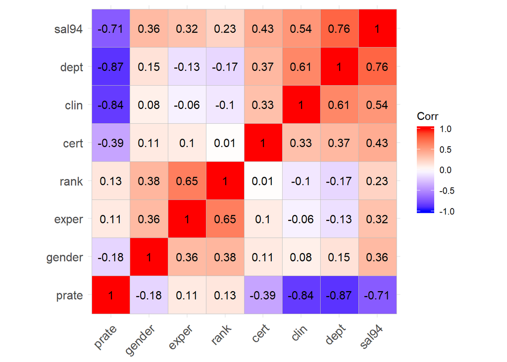

```r
## if we use collinearity to say we need to delete the prate
## reload the data to craete coorelation plot
law_col <- read_csv("./Lawsuit.csv") %>%
  janitor::clean_names() %>%
  dplyr::select(-sal95, -id)

corr <- round(cor(law_col), 3)
ggcorrplot(corr, hc.order = TRUE, type = "full", lab = TRUE)
```

```r
## vif when 'prate' is still in
law_vif <- law_df %>%
  dplyr::select(-sal95, -id, -dif_sal)
all_vb <- lm(sal94 ~., data = law_vif)
vif(all_vb)
```

```
##      deptPhysiology        deptGenetics      deptPediatrics        deptMedicine
##            1.607184            1.629419            4.282664            6.379551
##         deptSurgery          gendermale        clinresearch certBoard certified
##            7.215586            1.443762            5.877635            1.329952
##               prate               exper       rankassociate            rankfull
##           16.626048            1.884661            1.508016            2.225837
```

Maybe we use the summary result to say that the ‘prate’ should be deleted from the analysis other than dept…..